```python
import matplotlib.pyplot as plt
import numpy as np
import pandas as pd
```

```python
import matplotlib.pyplot as plt
import warnings
```

# Data Import

```python
CS = pd.read_csv('CollegeScorecard.csv')
CS
```

|  | UNITID | OPEID | opeid6 | INSTNM | CITY | STABBR | ZIP | AccredAgency | INSTURL | NPCURL | ... | COMPL_RPY_3YR_RT_SUPP | NONCOM_RPY_3YR_RT_SUPP | DEP_RPY_3YR_RT_SUPP | IND_RPY_3YR_RT_SUPP | PELL_RPY_3YR_RT_SUPP | NOPELL_RPY_3YR_RT_SUPP | FEMALE_RPY_3YR_RT_SUPP | MALE_RPY_3YR_RT_SUPP | FIRSTGEN_RPY_3YR_RT_SUPP | NOTFIRSTGEN_RPY_3YR_RT_SUPP |
| --- | --- | --- | --- | --- | --- | --- | --- | --- | --- | --- | --- | --- | --- | --- | --- | --- | --- | --- | --- | --- | --- |
| 0 | 100654 | 100200 | 1002 | Alabama A & M University | Normal | AL | 35762 | Southern Association of Colleges and Schools C... | www.aamu.edu/ | galileo.aamu.edu/netpricecalculator/npcalc.htm | ... | 0.578873239 | 0.373790022 | 0.442857143 | 0.45890411 | 0.443586698 | 0.452513966 | 0.484818805 | 0.406 | 0.423580786 | 0.44245283 |
| 1 | 100663 | 105200 | 1052 | University of Alabama at Birmingham | Birmingham | AL | 35294-0110 | Southern Association of Colleges and Schools C... | www.uab.edu | www.collegeportraits.org/AL/UAB/estimator/agree | ... | 0.847800926 | 0.678748759 | 0.767798013 | 0.739164697 | 0.732297853 | 0.795454545 | 0.760521886 | 0.755344418 | 0.751552795 | 0.765074771 |
| 2 | 100690 | 2503400 | 25034 | Amridge University | Montgomery | AL | 36117-3553 | Southern Association of Colleges and Schools C... | www.amridgeuniversity.edu | tcc.noellevitz.com/(S(miwoihs5stz5cpyifh4nczu0... | ... | 0.807692308 | 0.61328125 | PrivacySuppressed | 0.641114983 | 0.600877193 | 0.775 | 0.610465116 | 0.686567164 | 0.632653061 | 0.65 |
| 3 | 100706 | 105500 | 1055 | University of Alabama in Huntsville | Huntsville | AL | 35899 | Southern Association of Colleges and Schools C... | www.uah.edu | finaid.uah.edu/ | ... | 0.892045455 | 0.689788054 | 0.800347222 | 0.75564409 | 0.738341969 | 0.851405622 | 0.768378651 | 0.79844098 | 0.778156997 | 0.791666667 |
| 4 | 100724 | 100500 | 1005 | Alabama State University | Montgomery | AL | 36104-0271 | Southern Association of Colleges and Schools C... | www.alasu.edu/email/index.aspx | www.alasu.edu/cost-aid/forms/calculator/index.... | ... | 0.482490272 | 0.315996848 | 0.32410212 | 0.350993377 | 0.320016821 | 0.380829016 | 0.364423718 | 0.286530612 | 0.315737052 | 0.334633385 |
| ... | ... | ... | ... | ... | ... | ... | ... | ... | ... | ... | ... | ... | ... | ... | ... | ... | ... | ... | ... | ... | ... |
| 7799 | 48285703 | 157107 | 1571 | Georgia Military College-Columbus Campus | Columbus | GA | 31909 | NaN | http://columbus.gmc.cc.ga.us/ | NaN | ... | 0.586956522 | 0.473891273 | 0.482781027 | 0.478442281 | 0.42789148 | 0.607753706 | 0.490091055 | 0.461751152 | 0.490384615 | 0.495152871 |
| 7800 | 48285704 | 157101 | 1571 | Georgia Military College-Valdosta Campus | Valdosta | GA | 31605 | NaN | http://valdosta.gmc.cc.ga.us/ | NaN | ... | 0.586956522 | 0.473891273 | 0.482781027 | 0.478442281 | 0.42789148 | 0.607753706 | 0.490091055 | 0.461751152 | 0.490384615 | 0.495152871 |
| 7801 | 48285705 | 157105 | 1571 | Georgia Military College-Warner Robins Campus | Warner Robins | GA | 31093 | NaN | http://robins.gmc.cc.ga.us/ | NaN | ... | 0.586956522 | 0.473891273 | 0.482781027 | 0.478442281 | 0.42789148 | 0.607753706 | 0.490091055 | 0.461751152 | 0.490384615 | 0.495152871 |
| 7802 | 48285706 | 157100 | 1571 | Georgia Military College-Online | Milledgeville | GA | 31061 | NaN | http://online.gmc.cc.ga.us/ | NaN | ... | 0.586956522 | 0.473891273 | 0.482781027 | 0.478442281 | 0.42789148 | 0.607753706 | 0.490091055 | 0.461751152 | 0.490384615 | 0.495152871 |
| 7803 | 48285707 | 157103 | 1571 | Georgia Military College-Stone Mountain | Stone Mountain | GA | 30083 | NaN | http://fairburn.gmc.cc.ga.us/ | NaN | ... | 0.586956522 | 0.473891273 | 0.482781027 | 0.478442281 | 0.42789148 | 0.607753706 | 0.490091055 | 0.461751152 | 0.490384615 | 0.495152871 |

7804 rows × 1725 columns

Here are the variables that we think may relate to the graduation rate and underpriveleged:

C150_4: completion rates for first-time, full-time students who begin school in the fall semester and complete within 150 percent of the expected time to completion

INEXPFTE: Instructional expenditures per FTE student

AVGFACSAL: average faculty salary

COSTT4_A: The average annual cost of attendance for academic year institutions

RET_FT4: retention rate of full-time students in the prior year, at four-year institution

INC_PCT_LO: the percentage of undergraduate students whose family incomes range is relatively low (0-30,000 dollars, which is the lowest range)

```python
#clean the data(keep the columns we are going to use)
CS1 = CS[['UNITID','INSTNM','C150_4','INEXPFTE', 'AVGFACSAL','COSTT4_A','RET_FT4','INC_PCT_LO']]
CS1
```

|  | UNITID | INSTNM | C150_4 | INEXPFTE | AVGFACSAL | COSTT4_A | RET_FT4 | INC_PCT_LO |
| --- | --- | --- | --- | --- | --- | --- | --- | --- |
| 0 | 100654 | Alabama A & M University | 0.2914 | 7459.0 | 7079.0 | 18888.0 | 0.6314 | PrivacySuppressed |
| 1 | 100663 | University of Alabama at Birmingham | 0.5377 | 17208.0 | 10170.0 | 19990.0 | 0.8016 | PrivacySuppressed |
| 2 | 100690 | Amridge University | 0.6667 | 5123.0 | 3849.0 | 12300.0 | 0.3750 | PrivacySuppressed |
| 3 | 100706 | University of Alabama in Huntsville | 0.4835 | 9352.0 | 9341.0 | 20306.0 | 0.8098 | 0.488624612 |
| 4 | 100724 | Alabama State University | 0.2517 | 7393.0 | 6557.0 | 17400.0 | 0.6219 | 0.688963211 |
| ... | ... | ... | ... | ... | ... | ... | ... | ... |
| 7799 | 48285703 | Georgia Military College-Columbus Campus | NaN | NaN | NaN | NaN | NaN | PrivacySuppressed |
| 7800 | 48285704 | Georgia Military College-Valdosta Campus | NaN | NaN | NaN | NaN | NaN | PrivacySuppressed |
| 7801 | 48285705 | Georgia Military College-Warner Robins Campus | NaN | NaN | NaN | NaN | NaN | PrivacySuppressed |
| 7802 | 48285706 | Georgia Military College-Online | NaN | NaN | NaN | NaN | NaN | PrivacySuppressed |
| 7803 | 48285707 | Georgia Military College-Stone Mountain | NaN | NaN | NaN | NaN | NaN | PrivacySuppressed |

7804 rows × 8 columns

```python
# clean data_ delete all non-valid data
CS1 = CS1.dropna(axis=0, how='any')
print (CS1)
```

```
      UNITID                               INSTNM  ...  RET_FT4         INC_PCT_LO
0     100654             Alabama A & M University  ...   0.6314  PrivacySuppressed
1     100663  University of Alabama at Birmingham  ...   0.8016  PrivacySuppressed
2     100690                   Amridge University  ...   0.3750  PrivacySuppressed
3     100706  University of Alabama in Huntsville  ...   0.8098        0.488624612
4     100724             Alabama State University  ...   0.6219        0.688963211
...      ...                                  ...  ...      ...                ...
7365  482635               DeVry University-Texas  ...   0.5224  PrivacySuppressed
7367  482653            DeVry University-Virginia  ...   0.6667  PrivacySuppressed
7368  482662          DeVry University-Washington  ...   0.6667  PrivacySuppressed
7369  482671           DeVry University-Wisconsin  ...   0.5000  PrivacySuppressed
7370  482680          University of North Georgia  ...   0.7964  PrivacySuppressed

[2160 rows x 8 columns]
```

```python
#clean data_delete all "privacySuppressed" data within "INC_PCT_LO" column
CS2 = CS1[(True^CS1['INC_PCT_LO'].isin(['PrivacySuppressed']))]
print(CS2)
```

```
      UNITID                               INSTNM  ...  RET_FT4   INC_PCT_LO
3     100706  University of Alabama in Huntsville  ...   0.8098  0.488624612
4     100724             Alabama State University  ...   0.6219  0.688963211
5     100751            The University of Alabama  ...   0.8700  0.302561681
9     100858                    Auburn University  ...   0.8946   0.27736704
10    100937          Birmingham Southern College  ...   0.8037  0.227488152
...      ...                                  ...  ...      ...          ...
7012  474890              College America-Phoenix  ...   0.2000  0.823376623
7062  475608                     Criswell College  ...   0.8065  0.503649635
7122  476717       Be'er Yaakov Talmudic Seminary  ...   0.8586  0.923913044
7196  480091     Bryant & Stratton College-Online  ...   0.0000  0.798746154
7323  482158         Middle Georgia State College  ...   0.7034   0.60874036

[1380 rows x 8 columns]
```

```python
CS3 = CS2[['C150_4','INEXPFTE', 'AVGFACSAL','COSTT4_A','RET_FT4','INC_PCT_LO']]
CS3
```

|  | C150_4 | INEXPFTE | AVGFACSAL | COSTT4_A | RET_FT4 | INC_PCT_LO |
| --- | --- | --- | --- | --- | --- | --- |
| 3 | 0.4835 | 9352.0 | 9341.0 | 20306.0 | 0.8098 | 0.488624612 |
| 4 | 0.2517 | 7393.0 | 6557.0 | 17400.0 | 0.6219 | 0.688963211 |
| 5 | 0.6665 | 9817.0 | 9605.0 | 26717.0 | 0.8700 | 0.302561681 |
| 9 | 0.6792 | 11324.0 | 9429.0 | 23788.0 | 0.8946 | 0.27736704 |
| 10 | 0.6192 | 9990.0 | 7513.0 | 44512.0 | 0.8037 | 0.227488152 |
| ... | ... | ... | ... | ... | ... | ... |
| 7012 | 0.4375 | 1899.0 | 3623.0 | 27752.0 | 0.2000 | 0.823376623 |
| 7062 | 0.1875 | 11899.0 | 6011.0 | 23168.0 | 0.8065 | 0.503649635 |
| 7122 | 0.7143 | 2510.0 | 1077.0 | 17099.0 | 0.8586 | 0.923913044 |
| 7196 | 0.1860 | 1721.0 | 3356.0 | 17894.0 | 0.0000 | 0.798746154 |
| 7323 | 0.1343 | 5823.0 | 5105.0 | 13472.0 | 0.7034 | 0.60874036 |

1380 rows × 6 columns

```python
X = CS3[["C150_4", "INEXPFTE", "AVGFACSAL",	"COSTT4_A",	"RET_FT4", "INC_PCT_LO"]]
```

```python
# data normalization
from sklearn.preprocessing import StandardScaler
s = StandardScaler()
X_scale = s.fit_transform(X)
X_scale = pd.DataFrame(X_scale, columns=X.columns, index=X.index)
X_scale.head()
```

|  | C150_4 | INEXPFTE | AVGFACSAL | COSTT4_A | RET_FT4 | INC_PCT_LO |
| --- | --- | --- | --- | --- | --- | --- |
| 3 | -0.050092 | 0.054866 | 1.223584 | -0.853551 | 0.609979 | 0.253816 |
| 4 | -1.172307 | -0.212576 | 0.032861 | -1.085395 | -0.491802 | 1.319763 |
| 5 | 0.835867 | 0.118347 | 1.336498 | -0.342073 | 0.962971 | -0.736175 |
| 9 | 0.897351 | 0.324082 | 1.261222 | -0.575753 | 1.107217 | -0.870228 |
| 10 | 0.606873 | 0.141965 | 0.441744 | 1.077633 | 0.574211 | -1.135620 |

```python
import seaborn as sns
```

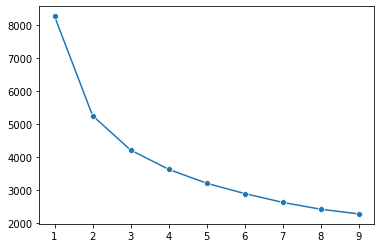

```python
from sklearn.cluster import KMeans
scope = range(1, 10)
sse = []
for k in scope:
    kmeans = KMeans(n_clusters=k)
    kmeans.fit (X_scale)
    sse.append(kmeans.inertia_)
plt.xticks(scope)
sns.lineplot(scope, sse, marker="o")
```

```python
#based on the graph above, we choose to use "4" clusters
kmeans = KMeans(n_clusters=4)
kmeans.fit(X)
cluster_kmeans = kmeans.predict(X)
```

```python
kmeans = KMeans(n_clusters=4)
kmeans.fit(X_scale)
#add cluster labels to the original data set
print("Labels：", kmeans.labels_)
```

```
Labels： [2 1 0 ... 1 1 1]
```

```python
CS3['kmeans.labels_']=kmeans.labels_
CS3
```

|  | C150_4 | INEXPFTE | AVGFACSAL | COSTT4_A | RET_FT4 | INC_PCT_LO | kmeans.labels_ |
| --- | --- | --- | --- | --- | --- | --- | --- |
| 3 | 0.4835 | 9352.0 | 9341.0 | 20306.0 | 0.8098 | 0.488624612 | 2 |
| 4 | 0.2517 | 7393.0 | 6557.0 | 17400.0 | 0.6219 | 0.688963211 | 1 |
| 5 | 0.6665 | 9817.0 | 9605.0 | 26717.0 | 0.8700 | 0.302561681 | 0 |
| 9 | 0.6792 | 11324.0 | 9429.0 | 23788.0 | 0.8946 | 0.27736704 | 0 |
| 10 | 0.6192 | 9990.0 | 7513.0 | 44512.0 | 0.8037 | 0.227488152 | 0 |
| ... | ... | ... | ... | ... | ... | ... | ... |
| 7012 | 0.4375 | 1899.0 | 3623.0 | 27752.0 | 0.2000 | 0.823376623 | 1 |
| 7062 | 0.1875 | 11899.0 | 6011.0 | 23168.0 | 0.8065 | 0.503649635 | 2 |
| 7122 | 0.7143 | 2510.0 | 1077.0 | 17099.0 | 0.8586 | 0.923913044 | 1 |
| 7196 | 0.1860 | 1721.0 | 3356.0 | 17894.0 | 0.0000 | 0.798746154 | 1 |
| 7323 | 0.1343 | 5823.0 | 5105.0 | 13472.0 | 0.7034 | 0.60874036 | 1 |

1380 rows × 7 columns

[figure not shown]

```python
fig = plt.figure(figsize=(20,20), dpi=100)
color = ["r", "g", "b","y"]
for i in range(4):
    d = CS3[kmeans.labels_ == i]
    plt.scatter( d.INC_PCT_LO, d.C150_4, color=color[i], label=f"SchoolType{i}")
    plt.legend()
    plt.rcParams['font.family']='SimHei'
    plt.rcParams['axes.unicode_minus']=False
```